# A1.1 Aprendizaje estadístico-automático

Preguntas iniciales:

¿Qué información te interesaría revisar si formaran parte del equipo de investigación?

¿Qué información te hubiera gustado recopilar y que actualmente no se encuentra en el estudio?

Para comenzar, se importa la librería pandas para extraer las primeras 10 líneas de información dentro de la base de datos.

```python
import pandas as pd
data = pd.read_csv("A1.1 Obesidad.csv")
print(data.head(10))
```

```
     Sexo  Edad  Estatura  Peso FamiliarConSobrepeso ComeMuchasCalorias  \
0  Female  21.0      1.62  64.0                  yes                 no
1  Female  21.0      1.52  56.0                  yes                 no
2    Male  23.0      1.80  77.0                  yes                 no
3    Male  27.0      1.80  87.0                   no                 no
4    Male  22.0      1.78  89.8                   no                 no
5    Male  29.0      1.62  53.0                   no                yes
6  Female  23.0      1.50  55.0                  yes                yes
7    Male  22.0      1.64  53.0                   no                 no
8    Male  24.0      1.78  64.0                  yes                yes
9    Male  22.0      1.72  68.0                  yes                yes

   ComeVegetales Fumador  ConsumoDeAgua      NivelDeObesidad
0            2.0      no            2.0        Normal_Weight
1            3.0     yes            3.0        Normal_Weight
2            2.0      no            2.0        Normal_Weight
3            3.0      no            2.0   Overweight_Level_I
4            2.0      no            2.0  Overweight_Level_II
5            2.0      no            2.0        Normal_Weight
6            3.0      no            2.0        Normal_Weight
7            2.0      no            2.0        Normal_Weight
8            3.0      no            2.0        Normal_Weight
9            2.0      no            2.0        Normal_Weight
```

Al analizar estos datos, considero que algunas otras variables que pudieran haber resultado útiles serían las siguientes:

- Porcentaje de grasa corporal (cuantitativa)
- Promedio de horas de sueño (cuantitativa)
- Nivel de actividad física (cualitativa)
- Si se presentan enfermedades asociadas o no (cualitativa)

Si yo fuera el líder del proyecto y quisiera realizar un estudio de inferencia, consideraría que la variable más adecuada a considerarse como salida, sería la de NivelDeObesidad, con la cual podemos obtener los promedios para cada tipo de nivel de obesidad dentro de la población.

A continuación se muestra la cantidad de personas que se encuentra dentro de cada categoría para la variable NivelDeObesidad:

```python
print(data.NivelDeObesidad.value_counts())
```

```
NivelDeObesidad
Obesity_Type_I         351
Obesity_Type_III       324
Obesity_Type_II        297
Overweight_Level_I     290
Overweight_Level_II    290
Normal_Weight          287
Insufficient_Weight    272
Name: count, dtype: int64
```

Conociendo esto, seleccioné las siguientes variables a graficar:

x = Edad,

y = NivelDeObesidad

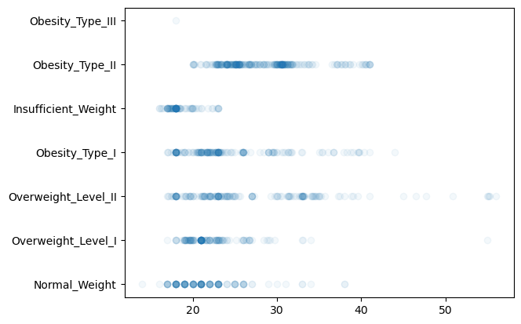

```python
%matplotlib inline
import matplotlib.pyplot as plt

plt.scatter(
    x = data.Edad[data.Sexo == "Male"],
    y = data.NivelDeObesidad[data.Sexo == "Male"],
    alpha = 0.05
)

plt.show()
```